# Good plot and bad plot assignment

Lipi

2023-03-30

# **Load the libraries**

```r
library(tidyverse)
library(here)
library(tidytuesdayR)
library(ggplot2)
library(ggthemes)
library(tidyr)
library(dplyr)
library(ggridges)
library(beyonce)
```

# **Read in the data**

```r
olympics <- readr::read_csv('https://raw.githubusercontent.com/rfordatascience/tidytuesday/master/data/2021/2021-07-27/olympics.csv')
View(olympics)
```

# **Creating a Bad Plot**

*Filter out the data of interest*

Here, I have filtered out year range: 1960 - 1965 and sport: Swimming.

```r
filtered_olympics_bad<-olympics %>%
  #drop_na() %>%
  filter(year >= "1960", year <= "1965", sport == "Swimming")
View(filtered_olympics_bad)
```

*Create a bad plot*

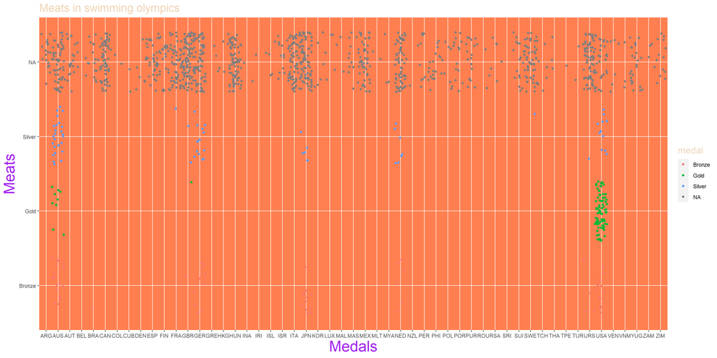

```r
filtered_olympics_bad %>% # uses this data
  ggplot(aes(x = noc, # makes a ggplot with given x and y axes
             y = medal,
             color = medal)) +
  geom_jitter(width = 0.5) + # adds a geom layer, dots
  labs(x = "Medals", y = "Meats",
       title = "Meats in swimming olympics") + # adds labels to axes
  theme(axis.title = element_text(size = 24, # fixes the size and color of axes titles
                                  color = "purple"),
      panel.background = element_rect(fill = "coral")) + # coloring the background
theme(title = element_text(size=15, color = "bisque2")) # fixes the size and color of plot title
```

*Save your Bad plot*

```r
ggsave(here("Good_plot_and_Bad_plot","Output","Bad_plot.png"),
       width = 16, height = 8) # in inches)
```

# Why is the above bad plot **BAD**?

**What is wrong with data?**

- Filtered data includes unnecessary N/A values
- Overlapping data points
- Background color does not contrast with color of the data points

**What is wrong with title?**

- Font size is too small
- Words do not make sense (meats?)
- Color is too light for the white background

**What’s wrong with axes titles and legend?**

- Axes titles are spelled incorrect and also flipped
- x-axis labels are too close to each other
- Color code of the legends are not related to the color of medals

Now let’s improvise our bad plot by keeping these points in consideration.

# **Creating a Good Plot**

*Filter out the data of your interest*

Here, I have filtered out year range: 1960 - 1980 and sport: Swimming.

```r
filtered_olympics_good<-olympics %>%
  drop_na() %>% # drops values with N/A
  filter(year >= "1960", year <= "1980", sport == "Swimming")
View(filtered_olympics_good)
```

*Create a good plot*

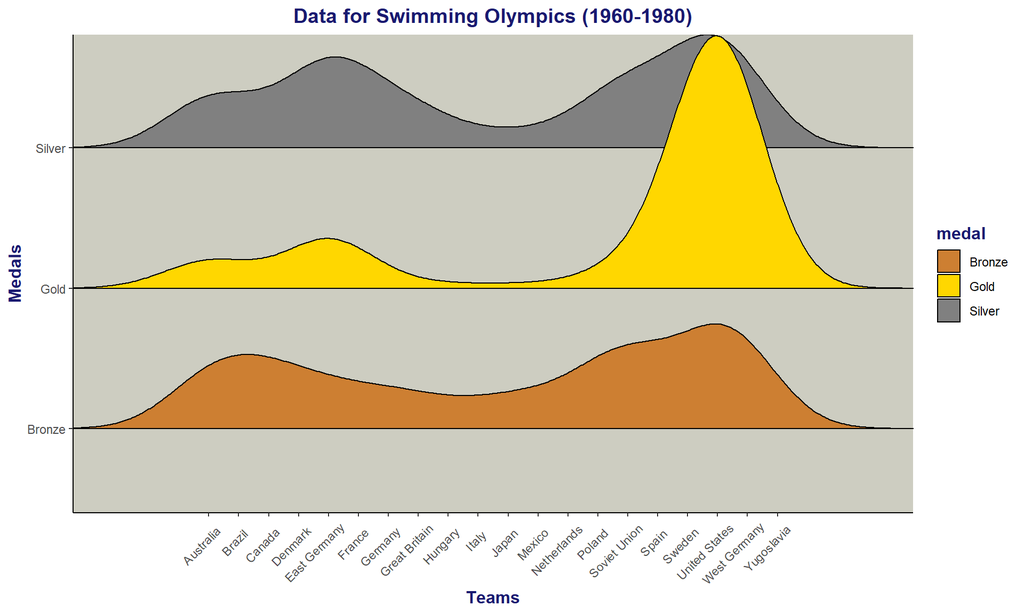

This depicts the medals won in Swimming by different teams between 1960-1980

```r
filtered_olympics_good %>% # uses this data
  ggplot(aes(x = team, # makes a ggplot with given x and y axes
             y = medal,
             group = medal, # remember to use "group" when using density gridges2
             fill = medal)) +
  geom_density_ridges2() +
  labs(x = "Teams", y = "Medals",
       title = "Data for Swimming Olympics (1960-1980)", size= 36, face = 'bold') + # adds labels to axes
  scale_fill_manual(values = c("#CD7F32", "#FFD700", "#808080")) + # color codes
  theme_classic() + # adds theme
  theme(axis.title = element_text(color = "midnightblue"),
      axis.text.x = element_text(angle = 45, vjust=0.8, hjust=0.8),
      panel.background = element_rect(fill = "ivory3")) + # adjusting the size, color and background
  theme(plot.title = element_text(hjust = 0.5)) + # aligns the title to center
theme(title = element_text(size=12, face='bold', color = "midnightblue")) # adjusting the size and color of title
```

*Save your Good plot*

```r
ggsave(here("Good_plot_and_Bad_plot","Output","Good_plot.png"),
       width = 10, height = 6) # in inches)
```

# Why is the above good plot **GOOD**?

- Title is precise, clear, and aligned
- Axes titles are spelled correctly and placed on the correct axes
- x-axis labels are clearly spaced
- Color of the background contrasts with that of ridges and also the labels
- Plot legends are color coded nicely with respective color of the medals
- Clear demarcation and visualization of data on the plot
- It has a caption describing the plot

THANK YOU! :)